# BANA7050_Final_Project

Author

Anish Goel

**Time Series decomposition and EDA**

**Dataset Description**

The data set used for this assignment is **“Birth Rate, crude(per 1000 people)”**, which is taken from The World bank’s website. Crude birth rate indicates the number of live births occurring during the year, per 1,000 population estimated at midyear. The data is published from Census reports and other statistical publications from national statistical offices of the respective countries. The variation in the feature is caused by a lot of factors such as **Contraceptive prevalence, Fertility rate, Life expectancy at birth, Mean age at first marriage etc**.

**Summary Statistics of the Data**

```
[1] "The Summary stastics for Annual birth rate is as follows:"
```

```
   Min. 1st Qu.  Median    Mean 3rd Qu.    Max.
  25.94   31.07   36.04   35.05   39.04   41.99
```

```
The standard deviation for the Annual birth rate is 4.851404 .
```

```
There are no potential outliers in our data as it is a decreasing trend with no abnormality present.
```

**Summary Visualization**

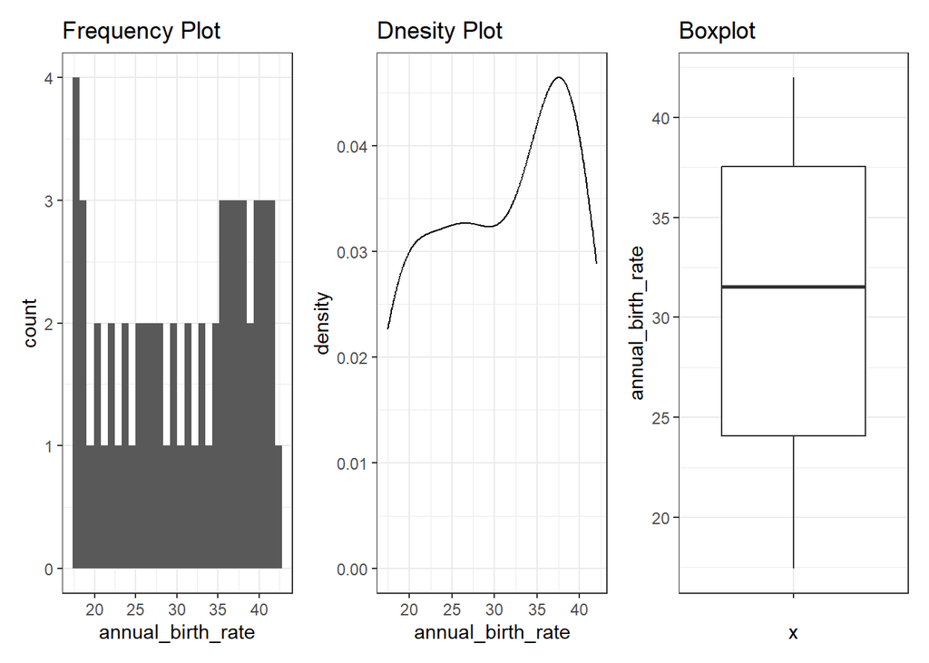

```r
hist <- birth_rate %>%
  ggplot() +
  ggtitle("Frequency Plot") +
  geom_histogram(aes(annual_birth_rate)) +
  theme_bw()

dens <- birth_rate %>%
  ggplot() +
  ggtitle("Dnesity Plot") +
  geom_density(aes(annual_birth_rate)) +
  theme_bw()

boxplot <- birth_rate %>%
  ggplot() +
  ggtitle("Boxplot") +
  geom_boxplot(aes("", annual_birth_rate)) +
  theme_bw()
hist + dens + boxplot
```

**Time Series Decomposition**

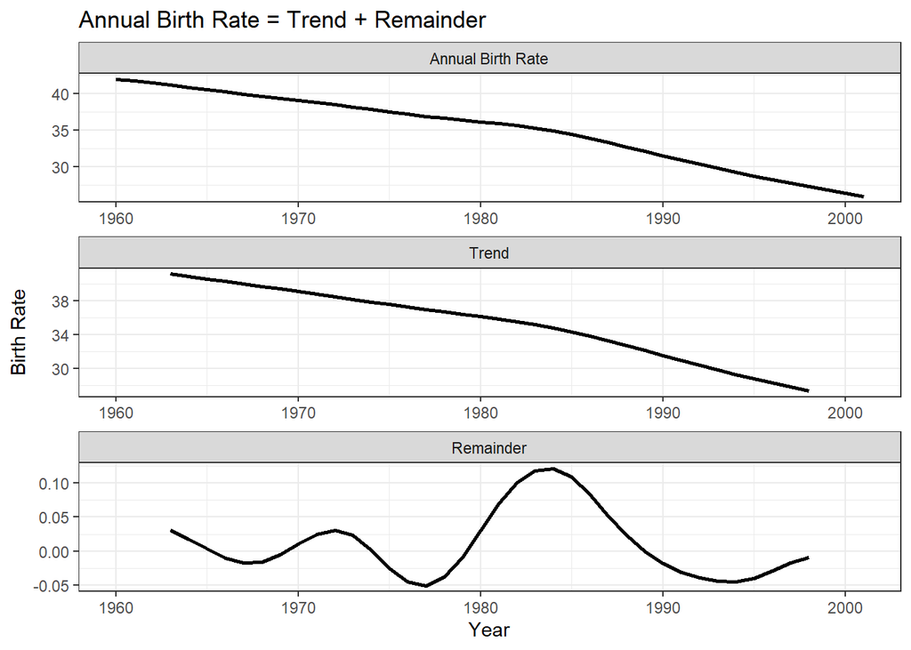

```r
birth_rate_decomp <- birth_rate_train %>%
  mutate(
    ma_7_center = rollapply(
      y,
      7,
      FUN = mean,
      align = "center", fill = NA
    )
  ) %>%
  mutate(resid = y - ma_7_center) %>%
  select(ds, y, ma_7_center, resid)

birth_rate_decomp_plot <- birth_rate_decomp %>%
  pivot_longer(
    y:resid,
    names_to = "decomposition",
    values_to = "y"
  ) %>%
  mutate(
    decomposition = case_when(
      decomposition == "y" ~ "Annual Birth Rate",
      decomposition == "ma_7_center" ~ "Trend",
      decomposition == "resid" ~ "Remainder"
    )
  ) %>%
  mutate(
    decomposition = factor(
      decomposition,
      labels = c(
        "Annual Birth Rate",
        "Trend",
        "Remainder"
      ),
      levels = c(
        "Annual Birth Rate",
        "Trend",
        "Remainder"
      )
    )
  ) %>%
  ggplot() +
  geom_line(aes(ds, y), size = 1) +
  facet_wrap(
    ~decomposition,
    nrow = 3,
    scales = "free"
  ) +
  theme_bw() +
  ylab("Birth Rate") +
  xlab("Year") +
  ggtitle(
    "Annual Birth Rate = Trend + Remainder"
  )

birth_rate_decomp_plot
```

**Moving Average Auto-correlation plot**

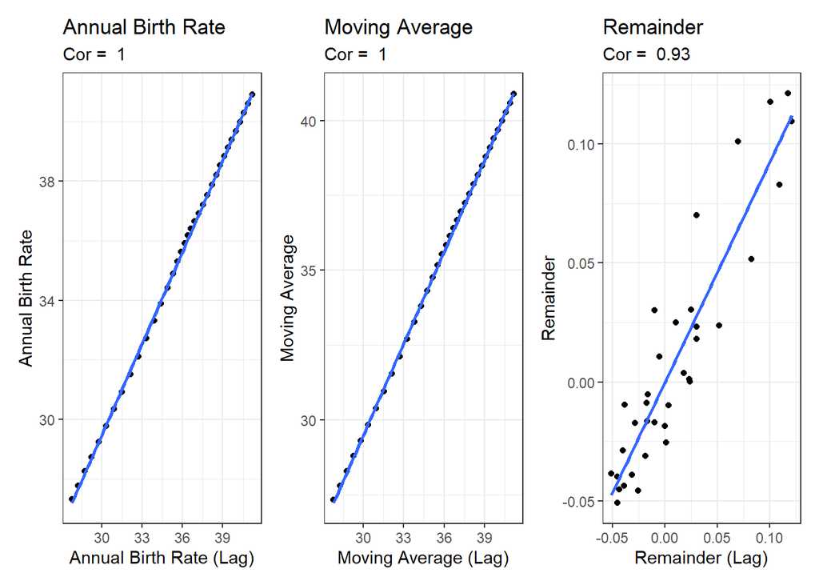

```r
birth_rate_decomp_lag <- birth_rate_decomp %>%
  drop_na() %>%
  mutate(across(where(is.numeric), list(lag = lag))) %>%
  select(
    ds, y, y_lag,
    ma_7_center, ma_7_center_lag, resid, resid_lag
  )

birth_rate_decomp_auto <- birth_rate_decomp_lag %>%
  drop_na()

cor_rate <- round(cor(birth_rate_decomp_auto$y_lag, birth_rate_decomp_auto$y), 2)
cor_ma <- round(cor(birth_rate_decomp_auto$ma_7_center_lag, birth_rate_decomp_auto$ma_7_center), 2)
cor_resid <- round(cor(birth_rate_decomp_auto$resid_lag, birth_rate_decomp_auto$resid), 2)

rate_plot <- birth_rate_decomp_auto %>%
  ggplot() +
  geom_point(aes(y_lag, y)) +
  geom_smooth(aes(y_lag, y), method = "lm", se = F) +
  labs(
    title = "Annual Birth Rate",
    subtitle = paste("Cor = ", cor_rate)
  ) +
  theme_bw()+
  ylab('Annual Birth Rate')+
  xlab('Annual Birth Rate (Lag)')

ma_7_center_plot <- birth_rate_decomp_auto %>%
  ggplot() +
  geom_point(aes(ma_7_center_lag, ma_7_center)) +
  geom_smooth(aes(ma_7_center_lag, ma_7_center), method = "lm", se = F) +
  labs(
    title = "Moving Average",
    subtitle = paste("Cor = ", cor_ma)
  ) +
  theme_bw()+
  ylab('Moving Average')+
  xlab('Moving Average (Lag)')

resid_plot <- birth_rate_decomp_auto %>%
  ggplot() +
  geom_point(aes(resid_lag, resid)) +
  geom_smooth(aes(resid_lag, resid), method = "lm", se = F) +
  labs(
    title = "Remainder",
    subtitle = paste("Cor = ", cor_resid)
  ) +
  theme_bw()+
  ylab('Remainder')+
  xlab('Remainder (Lag)')

rate_plot + ma_7_center_plot + resid_plot
```

We can observe that there is a lot of auto-correlation still present in our remainder which signifies that the **remainder is not white noise**. This implicates that there are other dynamics that we would want to model. Also, we know that annual data typically does not contain any seasonality and hence we would not be using a classical decomposition method or the STL decomposition as it would try to depict seasonality which is clearly not present in our data.

**Arima Modeling**

**Rolling Average**

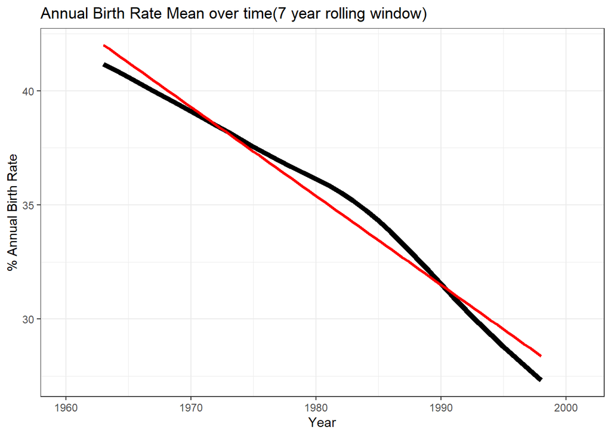

```r
birth_rate_roll_mean <- birth_rate_roll %>%
  ggplot() +
  geom_line(aes(ds, birth_rate_mean), size= 2) +
  geom_smooth(aes(ds, birth_rate_mean),method = 'lm', se = F, color = 'red', size = 1.2) +
  theme_bw() +
  ylab("% Annual Birth Rate") +
  xlab("Year") +
  ggtitle("Annual Birth Rate Mean over time(7 year rolling window)")
birth_rate_roll_mean
```

We can clearly see that this a **mean non-stationary time-series** as the center-aligned moving average is also following a downward trend.

**Rolling Standard Deviation**

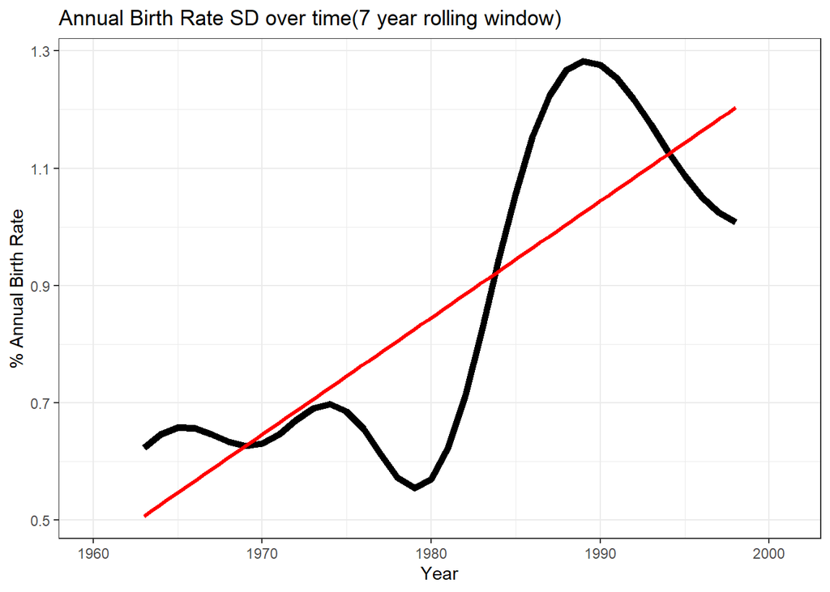

```r
birth_rate_roll_sd <- birth_rate_roll %>%
  ggplot() +
  geom_line(aes(ds, birth_rate_sd), size= 2) +
  geom_smooth(aes(ds, birth_rate_sd), method = 'lm', se = F, color = 'red', size = 1.2) +
  theme_bw() +
  ylab("% Annual Birth Rate") +
  xlab("Year") +
  ggtitle("Annual Birth Rate SD over time(7 year rolling window)")
birth_rate_roll_sd
```

We can clearly see that this a **variance non-stationary time-series**.

**Log and Box-Cox Transformation**

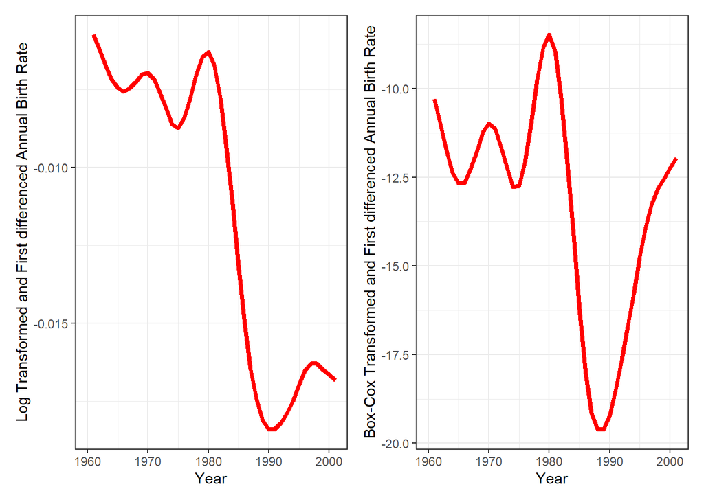

```r
birth_rate_trans3 <- birth_rate_diff %>%
  ggplot() +
  geom_line(aes(ds, birth_rate_log_diff), color = 'red', size = 1.5) +
#  geom_smooth(aes(Year, birth_rate_log_diff), method = 'lm', se = F) +
  theme_bw() +
  ylab("Log Transformed and First differenced Annual Birth Rate") +
  xlab("Year")

birth_rate_trans4 <- birth_rate_diff %>%
  ggplot() +
  geom_line(aes(ds, birth_rate_boxcox_diff), color = 'red', size = 1.5) +
#  geom_smooth(aes(Year, birth_rate_boxcox_diff), method = 'lm', se = F) +
  theme_bw() +
  ylab("Box-Cox Transformed and First differenced Annual Birth Rate") +
  xlab("Year")

birth_rate_trans3 + birth_rate_trans4
```

Our Box-Cox transformation seems to have less variability. We will conduct KPSS test to check for further stationarity.

**KPSS Test**

```r
log_diff_kpss <- birth_rate_diff %>%
  features(birth_rate_log_diff, unitroot_kpss)
log_diff_kpss
```

```
# A tibble: 1 × 2
  kpss_stat kpss_pvalue
      <dbl>       <dbl>
1     0.928        0.01
```

```r
boxcox_diff_kpss <- birth_rate_diff %>%
  features(birth_rate_boxcox_diff, unitroot_kpss)
boxcox_diff_kpss
```

```
# A tibble: 1 × 2
  kpss_stat kpss_pvalue
      <dbl>       <dbl>
1     0.386      0.0832
```

We will thus move forward with our **box-cox transformed and first differenced time-series.**

**ACF/PACF plots and Interpretation**

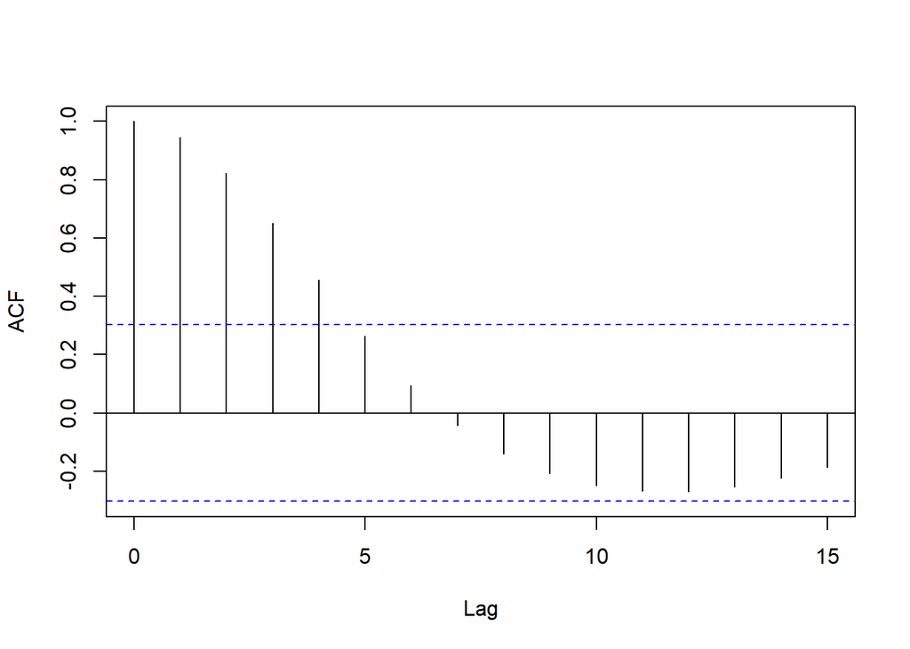

```r
a <- acf(birth_rate_diff$birth_rate_boxcox_diff,lag.max=15,na.action=na.pass,plot=FALSE)
plot(a,main=" ")
```

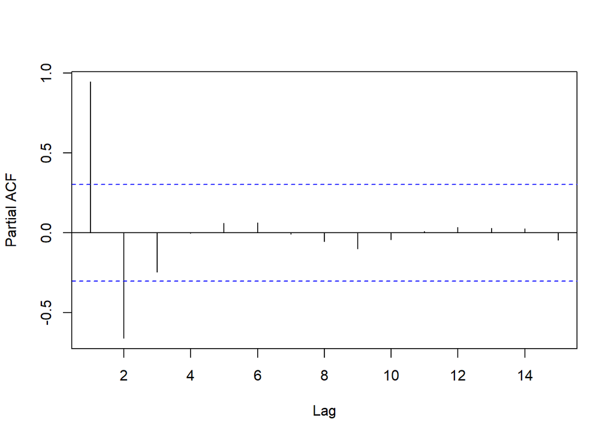

```r
b <- pacf(birth_rate_diff$birth_rate_boxcox_diff,lag.max=15,na.action=na.pass,plot=FALSE)
plot(b,main=" ")
```

We observe that ACF shows dampening auto-correlation and there are two significant lags in our PACF plot which indicates this to be an **AR(2) process.** However, we can also intuitively feel it to be an **MA(4) process**, as there is not an exactly perfect dampening. Also, there is **no seasonality** present in our data. We will test our ARIMA models for: **ARIMA(2,0,2), ARIMA(2,1,2), ARIMA(2,2,2), ARIMA(2,0,3), ARIMA(2,1,3), ARIMA(2,2,3), ARIMA(2,3,3), ARIMA(2,0,4), ARIMA(2,1,4), ARIMA(2,2,4), ARIMA(2,3,4), ARIMA(2,4,4)**

**Fitting Various ARIMA models**

```r
models_bic = birth_rate_1 %>%
  model(
    mod1 = ARIMA(birth_rate_boxcox_diff~pdq(2,0,2)+PDQ(0,0,0)),
    mod2 = ARIMA(birth_rate_boxcox_diff~pdq(2,1,2)+PDQ(0,0,0)),
    mod3 = ARIMA(birth_rate_boxcox_diff~pdq(2,2,2)+PDQ(0,0,0)),
    mod4 = ARIMA(birth_rate_boxcox_diff~pdq(2,0,3)+PDQ(0,0,0)),
    mod5 = ARIMA(birth_rate_boxcox_diff~pdq(2,1,3)+PDQ(0,0,0)),
    mod6 = ARIMA(birth_rate_boxcox_diff~pdq(2,2,3)+PDQ(0,0,0)),
    mod7 = ARIMA(birth_rate_boxcox_diff~pdq(2,3,3)+PDQ(0,0,0)),
    mod8 = ARIMA(birth_rate_boxcox_diff~pdq(2,0,4)+PDQ(0,0,0)),
    mod9 = ARIMA(birth_rate_boxcox_diff~pdq(2,1,4)+PDQ(0,0,0)),
    mod10 = ARIMA(birth_rate_boxcox_diff~pdq(2,2,4)+PDQ(0,0,0)),
    mod11 = ARIMA(birth_rate_boxcox_diff~pdq(2,3,4)+PDQ(0,0,0)),
    mod12 = ARIMA(birth_rate_boxcox_diff~pdq(2,4,4)+PDQ(0,0,0)),
  )



models_bic %>%
  glance() %>%
  arrange(BIC)
```

```
# A tibble: 7 × 8
  .model sigma2 log_lik    AIC   AICc    BIC ar_roots  ma_roots
  <chr>   <dbl>   <dbl>  <dbl>  <dbl>  <dbl> <list>    <list>
1 mod3   0.0231   18.9  -27.9  -26.2  -19.3  <cpl [2]> <cpl [2]>
2 mod5   0.0216   19.9  -27.8  -25.4  -17.3  <cpl [2]> <cpl [3]>
3 mod10  0.0197   20.9  -27.8  -24.4  -15.8  <cpl [2]> <cpl [4]>
4 mod6   0.0280   15.2  -18.5  -16.0   -8.19 <cpl [2]> <cpl [3]>
5 mod8   0.0244   16.3  -16.6  -12.4   -2.50 <cpl [2]> <cpl [4]>
6 mod4   0.0297    9.64  -7.28  -4.95   3.29 <cpl [2]> <cpl [3]>
7 mod1   0.0315    7.71  -5.42  -3.80   3.38 <cpl [2]> <cpl [2]>
```

The best model as per our BIC value is **ARIMA(2,2,2).**

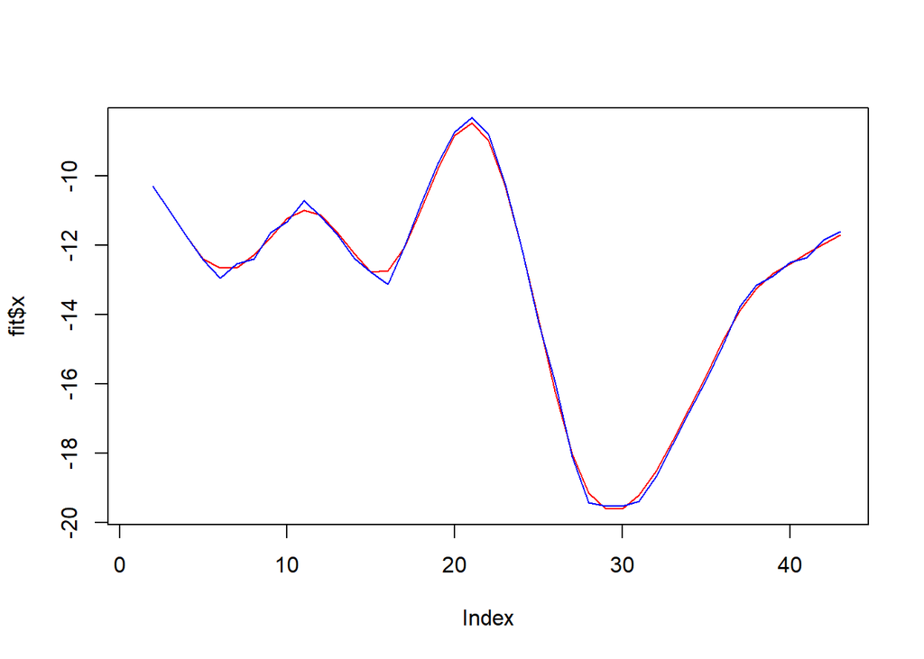

```r
fit <- Arima(birth_rate_1$birth_rate_boxcox_diff,order=c(2,2,2))

plot(fit$x,col="white")
lines(fit$x,col="red", size = 2)
lines(fitted(fit),col="blue", size = 2)
```

**The in-sample predicted values tend to follow the trends in the data.**

**Meta Prophet Model**

**Time-series Decomposition**

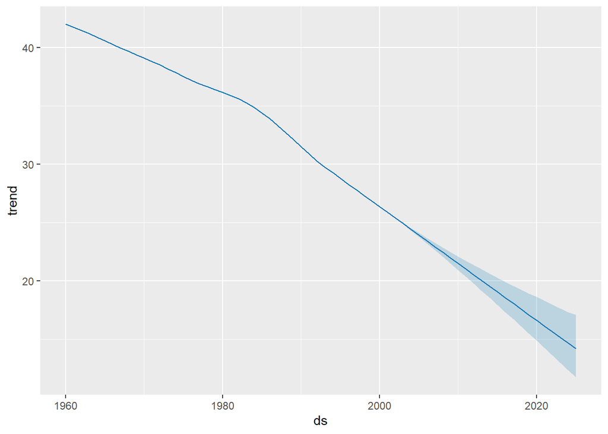

```r
prophet_plot_components(birth_rate_prophet_model,birth_rate_prophet_forecast)
```

Our Time-series does not contain any seasonality and hence we **plot the trend line** for time-series decomposition.

**Default Changepoint plot**

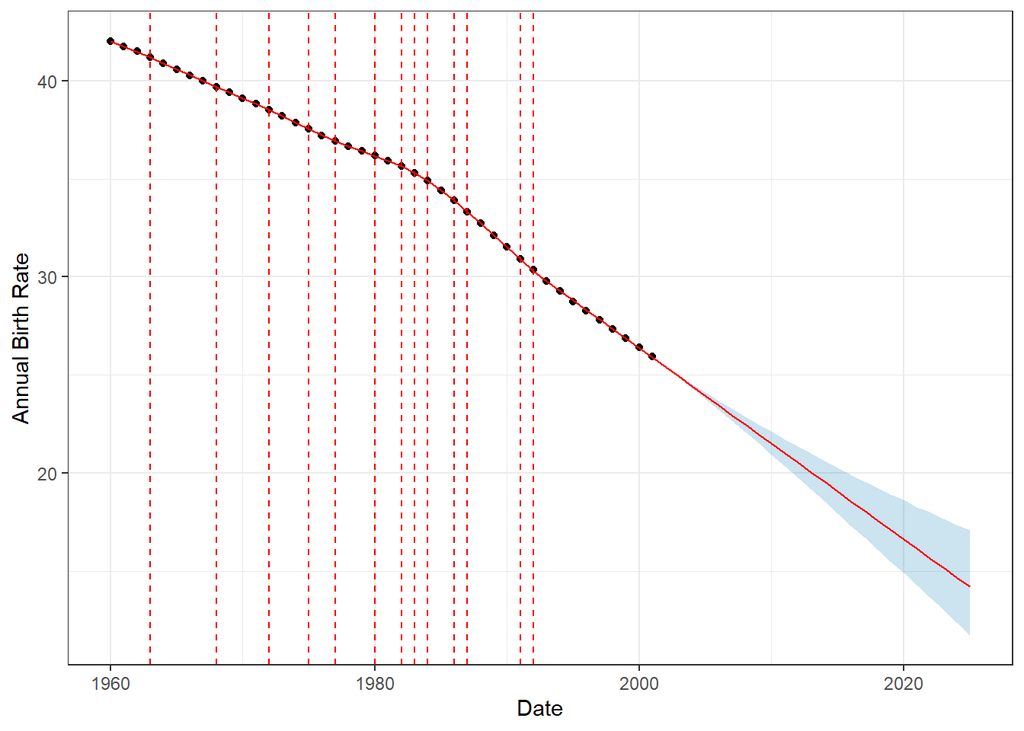

```r
plot(birth_rate_prophet_model,birth_rate_prophet_forecast)+
  add_changepoints_to_plot(birth_rate_prophet_model) +
  ylab("Annual Birth Rate") +
  xlab("Date") +
  theme_bw()
```

The **Dark red line** is our trend line and the **Dotted red line** represents the changepoints detected by our prophet model. The algorithm finally came up with **13 Changepoints** for our time-series.

This does not really make sense for our data by sheer visualization. We will make our model less flexible by decreasing number of changepoints or the changepoint scale, so that the model is not over-fitted.

**Changing the hyperparameters**

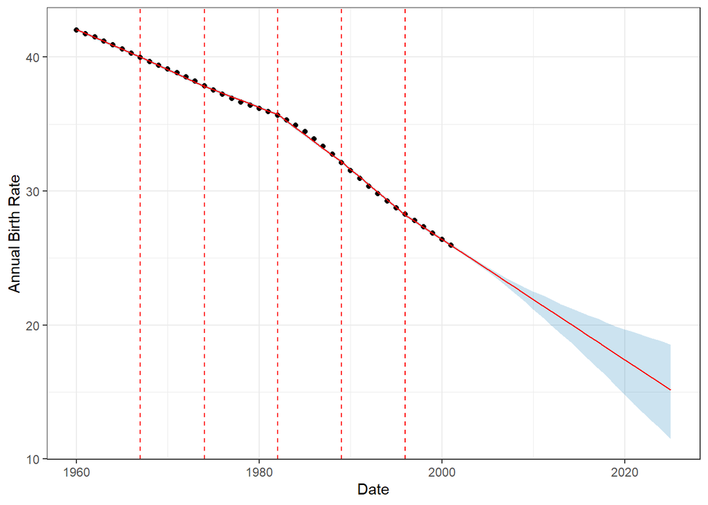

```r
birth_rate_prophet_model1 <- prophet(birth_rate_train, n.changepoints = 5,  changepoint.range = 0.9, changepoint.prior.scale = 0.04, yearly.seasonality =  FALSE)
birth_rate_prophet_future1 <- make_future_dataframe(birth_rate_prophet_model1, periods = 24, freq = 'year')
birth_rate_prophet_forecast1 <- predict(birth_rate_prophet_model1, birth_rate_prophet_future1)
plot(birth_rate_prophet_model1,birth_rate_prophet_forecast1)+
  add_changepoints_to_plot(birth_rate_prophet_model1) +
  ylab("Annual Birth Rate") +
  xlab("Date") +
  theme_bw()
```

**Setting Saturation Points and plotting a Logistic trend for forecasting**

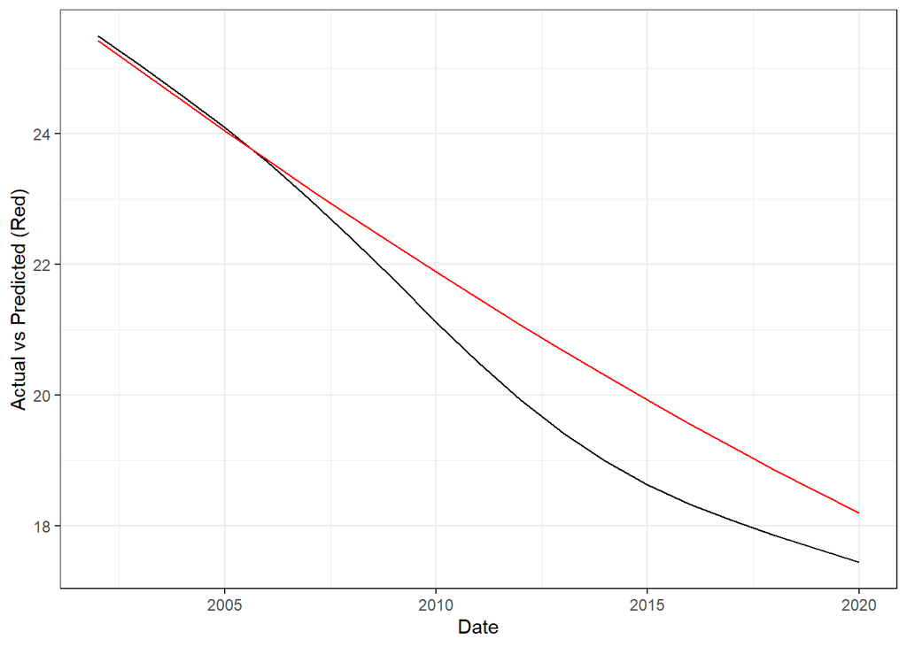

```r
birth_rate_prophet_future2 <- make_future_dataframe(birth_rate_prophet_model, periods = 24, freq = 'year')

# Set "floor" in training data
birth_rate_train$floor = 10
birth_rate_train$cap = 50
birth_rate_prophet_future$floor = 10
birth_rate_prophet_future$cap = 50

# Set floor in forecast data
birth_rate_prophet_future2$floor = 10
birth_rate_prophet_future2$cap = 50
birth_rate_prophet_model2 <- prophet(birth_rate_train,growth = 'logistic', yearly.seasonality = FALSE)
birth_rate_prophet_forecast2 <- predict(birth_rate_prophet_model2, birth_rate_prophet_future2)

forecast_plot_data = birth_rate_prophet_forecast2 %>%
  as_tibble() %>%
  mutate(ds = as.Date(ds)) %>%
  filter(ds>=ymd("2002-01-01") & ds <= ymd("2020-01-01"))

ggplot()+
geom_line(aes(birth_rate_test$ds,birth_rate_test$y))+
geom_line(aes(forecast_plot_data$ds,forecast_plot_data$yhat),color='red')+
theme_bw()+
ylab('Actual vs Predicted (Red)')+
xlab('Date')
```

We can see that **Logistic trend does not fit really well** for our time-series.

**Model Comparison and Validation**

**Cross Validation**

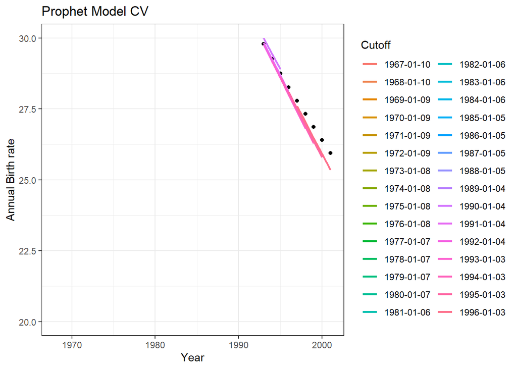

```r
df.cv <- cross_validation(birth_rate_prophet_model, initial = 7*365, period = 365, horizon = 5*365, units = 'days') %>%
  mutate(ds=year(ds))

df.cv %>%
  ggplot() +
  geom_point(aes(ds,y)) +
  geom_line(aes(ds,yhat,color = factor(cutoff)),size = 1) +
  theme_bw() +
  ggtitle("Prophet Model CV") +
  xlab("Year") +
  ylab("Annual Birth rate") +
  scale_color_discrete(name = 'Cutoff')+
  ylim(20,30)
```

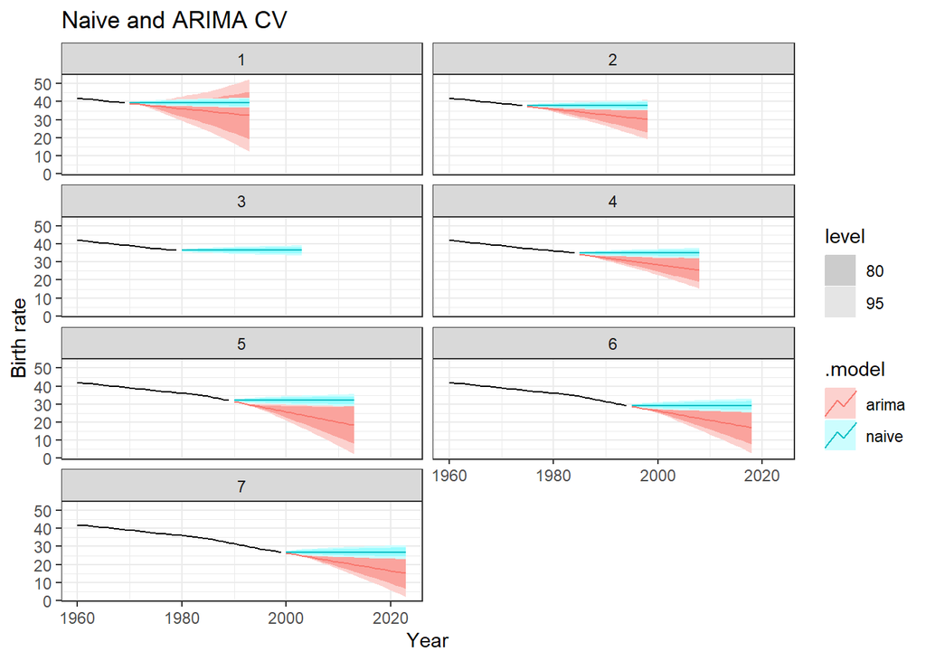

```r
birthrate_train_cv_data = birth_rate_train1 %>%
  stretch_tsibble(.init = 10, .step = 5)

birthrate_cv_forecast = birthrate_train_cv_data %>%
  model(naive = NAIVE(y),
  arima = ARIMA(y~pdq(2,2,2))) %>%
  forecast(h = 24)

birthrate_cv_forecast %>%
  autoplot(birthrate_train_cv_data)+
  facet_wrap(~.id,nrow=4)+
  theme_bw()+
  ggtitle('Naive and ARIMA CV') +
  ylab('Birth rate') +
  xlab('Year')
```

**Comparing RMSE**

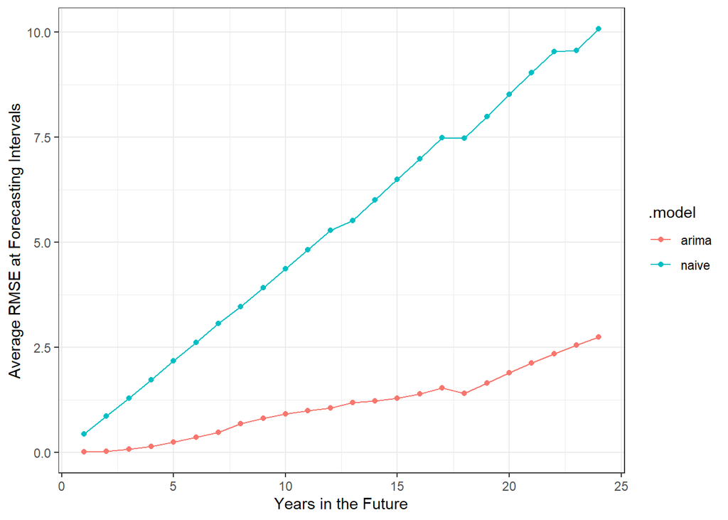

```r
birthrate_cv_forecast %>%
  group_by(.id,.model) %>%
  mutate(h = row_number()) %>%
  ungroup() %>%
  as_fable(response = "y", distribution = y) %>%
  accuracy(birth_rate_train1, by = c("h", ".model")) %>%
  ggplot(aes(x = h, y = RMSE,color=.model)) +
  geom_point()+
  geom_line()+
  theme_bw()+
  ylab('Average RMSE at Forecasting Intervals')+
  xlab('Years in the Future')
```

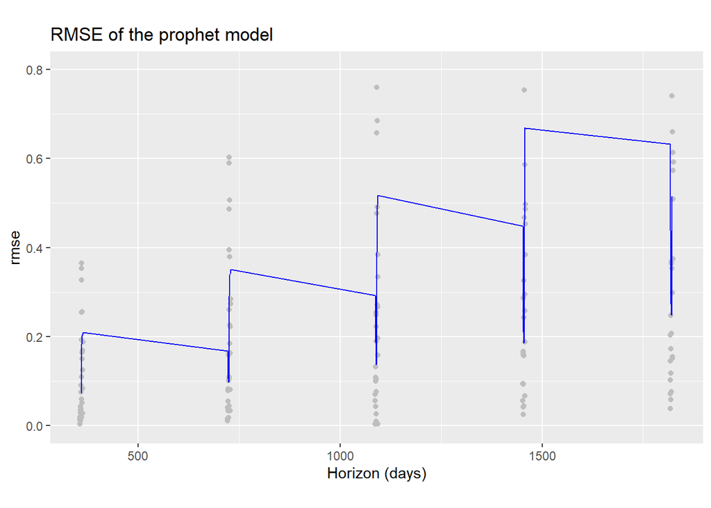

```r
df.cv1 <- cross_validation(birth_rate_prophet_model, initial = 7*365, period = 365, horizon = 5*365, units = 'days')
plot_cross_validation_metric(df.cv1, metric = 'rmse') +
  ggtitle("RMSE of the prophet model") +
  ylim(0, 0.8)
```

**Final Model**

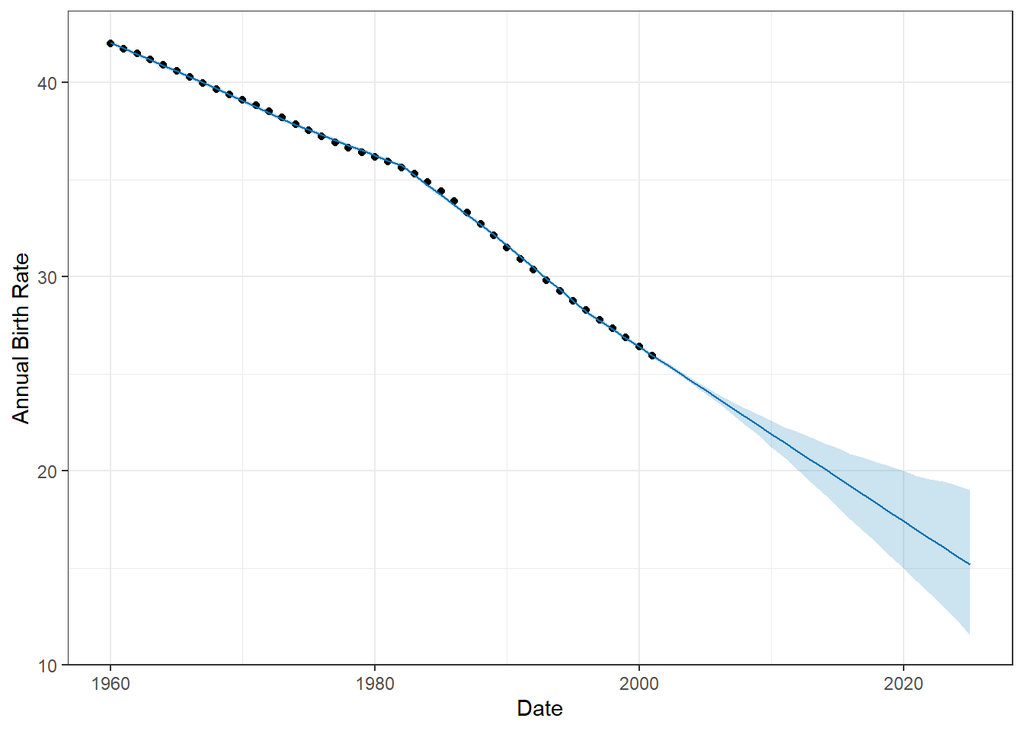

```r
birth_rate_prophet_model1 <- prophet(birth_rate_train, n.changepoints = 5,  changepoint.range = 0.9, changepoint.prior.scale = 0.04, yearly.seasonality =  FALSE)
birth_rate_prophet_future1 <- make_future_dataframe(birth_rate_prophet_model1, periods = 24, freq = 'year')
birth_rate_prophet_forecast1 <- predict(birth_rate_prophet_model1, birth_rate_prophet_future1)
plot(birth_rate_prophet_model1,birth_rate_prophet_forecast1)+
  ylab("Annual Birth Rate") +
  xlab("Date") +
  theme_bw()
```

```r
tail(birth_rate_prophet_forecast2[,1:2])
```

```
           ds    trend
61 2020-01-01 18.19320
62 2021-01-01 17.87496
63 2022-01-01 17.56697
64 2023-01-01 17.26829
65 2024-01-01 16.97887
66 2025-01-01 16.69786
```

**The forecast makes sense given the history of our data as there is a steady decline in annual birth rate.**